# Analyse exploratoire (EDA) de la table Collision

**Données :** STATS19 du Department for Transport (Grande-Bretagne), collisions corporelles 2021-2025.

**Objectif de ce notebook :** comprendre le contenu de la table *avant* tout nettoyage, repérer les problèmes de qualité, et justifier les choix faits ensuite dans `clean_collision.py`.

**Plan**

1. Chargement et structure
2. Identifiant et doublons
3. Valeurs manquantes (codées `-1`, `9`, `99`)
4. Rupture de schéma 2024-2025
5. Valeurs extrêmes
6. La cible : la gravité (`collision_severity`)
7. Biais lié au changement de mode de saisie
8. Analyse temporelle
9. Gravité selon les conditions (vitesse, zone, lumière…)
10. Géographie
11. Liens avec la gravité (V de Cramér)
12. Synthèse : constats → décisions de nettoyage

## 1. Chargement et structure

```python
import zipfile
from pathlib import Path

import numpy as np
import pandas as pd
import matplotlib.pyplot as plt
import seaborn as sns
from scipy.stats import chi2_contingency

sns.set_theme(style="whitegrid")
plt.rcParams["figure.dpi"] = 110
pd.set_option("display.max_columns", 60, "display.width", 200)

# --- Recherche automatique du fichier brut (dossier data_brut) ---
for base in [Path("data_brut"), Path("../data_brut")]:
    files = sorted(p for p in base.glob("*collision*") if p.suffix.lower() in (".zip", ".csv"))
    if files:
        DATA_PATH = files[0]
        break
else:
    raise FileNotFoundError("Placez le fichier brut dans le dossier data_brut/")
print("Fichier utilisé :", DATA_PATH)

def read_raw(path):
    if path.suffix.lower() == ".zip":
        with zipfile.ZipFile(path) as z:
            name = [n for n in z.namelist()
                    if n.lower().endswith(".csv") and not n.startswith("__MACOSX")][0]
            with z.open(name) as f:
                return pd.read_csv(f, low_memory=False)
    return pd.read_csv(path, low_memory=False)

df = read_raw(DATA_PATH)
print(f"{df.shape[0]:,} lignes x {df.shape[1]} colonnes")
df.head(3)
```

```
Fichier utilisé : ../data_brut/dft-road-casualty-statistics-collision-last-5-years 2.csv.zip
```

```
513,801 lignes x 44 colonnes
```

|  | collision_index | collision_year | collision_ref_no | location_easting_osgr | location_northing_osgr | longitude | latitude | police_force | collision_severity | number_of_vehicles | number_of_casualties | date | day_of_week | time | local_authority_district | local_authority_ons_district | local_authority_highway | local_authority_highway_current | first_road_class | first_road_number | road_type | speed_limit | junction_detail_historic | junction_detail | junction_control | second_road_class | second_road_number | pedestrian_crossing_human_control_historic | pedestrian_crossing_physical_facilities_historic | … |
| --- | --- | --- | --- | --- | --- | --- | --- | --- | --- | --- | --- | --- | --- | --- | --- | --- | --- | --- | --- | --- | --- | --- | --- | --- | --- | --- | --- | --- | --- | --- |
| 0 | 202417H105824 | 2024 | 17H105824 | 448628.0 | 533968.0 | -1.24700 | 54.69840 | 17 | 2 | 2 | 1 | 03/10/2024 | 5 | 16:06 | -1 | E06000001 | E06000001 | E06000001 | 6 | 0 | 6 | 30 | -1 | 0 | -1 | -1 | -1 | -1 | -1 | … |
| 1 | 202517M115025 | 2025 | 17M115025 | 452379.0 | 519038.0 | -1.19147 | 54.56387 | 17 | 2 | 2 | 1 | 29/11/2025 | 7 | 16:34 | -1 | E06000002 | E06000002 | E06000002 | 3 | 171 | 6 | 30 | -1 | 13 | 4 | 6 | 0 | -1 | -1 | … |
| 2 | 202517L306225 | 2025 | 17L306225 | 459273.0 | 523811.0 | -1.08390 | 54.60600 | 17 | 3 | 2 | 3 | 01/06/2025 | 1 | 22:07 | -1 | E06000003 | E06000003 | E06000003 | 3 | 1042 | 6 | 30 | -1 | 13 | 4 | 6 | 0 | -1 | -1 | … |

```python
# Résumé de chaque colonne : type, nombre de valeurs distinctes, exemple
summary = pd.DataFrame({
    "type": df.dtypes.astype(str),
    "valeurs_distinctes": df.nunique(),
    "NaN": df.isna().sum(),
    "exemple": df.iloc[0],
})
summary
```

|  | type | valeurs_distinctes | NaN | exemple |
| --- | --- | --- | --- | --- |
| collision_index | str | 513801 | 0 | 202417H105824 |
| collision_year | int64 | 5 | 0 | 2024 |
| collision_ref_no | str | 510837 | 0 | 17H105824 |
| location_easting_osgr | float64 | 245276 | 53 | 448628.0 |
| location_northing_osgr | float64 | 263601 | 53 | 533968.0 |
| longitude | float64 | 437862 | 53 | -1.247 |
| latitude | float64 | 412450 | 53 | 54.6984 |
| police_force | int64 | 44 | 0 | 17 |
| collision_severity | int64 | 3 | 0 | 2 |
| number_of_vehicles | int64 | 19 | 0 | 2 |
| number_of_casualties | int64 | 26 | 0 | 1 |
| date | str | 1826 | 0 | 03/10/2024 |
| day_of_week | int64 | 7 | 0 | 5 |
| time | str | 1440 | 0 | 16:06 |
| local_authority_district | int64 | 15 | 0 | -1 |
| local_authority_ons_district | str | 370 | 0 | E06000001 |
| local_authority_highway | str | 211 | 0 | E06000001 |
| local_authority_highway_current | str | 208 | 0 | E06000001 |
| first_road_class | int64 | 7 | 0 | 6 |
| first_road_number | int64 | 3616 | 0 | 0 |
| road_type | int64 | 6 | 0 | 6 |
| speed_limit | int64 | 7 | 0 | 30 |
| junction_detail_historic | int64 | 11 | 0 | -1 |
| junction_detail | int64 | 8 | 0 | 0 |
| junction_control | int64 | 6 | 0 | -1 |
| second_road_class | int64 | 9 | 0 | -1 |
| second_road_number | int64 | 3356 | 0 | -1 |
| pedestrian_crossing_human_control_historic | int64 | 5 | 0 | -1 |
| pedestrian_crossing_physical_facilities_historic | int64 | 8 | 0 | -1 |
| pedestrian_crossing | int64 | 10 | 0 | 0 |
| light_conditions | int64 | 6 | 0 | 1 |
| weather_conditions | int64 | 10 | 0 | 1 |
| road_surface_conditions | int64 | 7 | 0 | 1 |
| special_conditions_at_site | int64 | 10 | 0 | -1 |
| carriageway_hazards_historic | int64 | 8 | 0 | -1 |
| carriageway_hazards | int64 | 14 | 0 | 0 |
| urban_or_rural_area | int64 | 4 | 0 | 1 |
| did_police_officer_attend_scene_of_accident | int64 | 3 | 0 | 1 |
| trunk_road_flag | int64 | 3 | 0 | 2 |
| lsoa_of_accident_location | str | 35630 | 0 | E01012005 |
| enhanced_severity_collision | int64 | 6 | 0 | 7 |
| collision_injury_based | int64 | 2 | 0 | 1 |
| collision_adjusted_severity_serious | float64 | 25538 | 0 | 1.0 |
| collision_adjusted_severity_slight | float64 | 25539 | 0 | 0.0 |

**Lecture :** 44 colonnes, presque toutes des **codes numériques** (catégories) et non des mesures. Aucune cellule n'est un vrai `NaN` (hors 53 coordonnées) : les manquants sont cachés dans des codes. `date` et `time` sont des chaînes de caractères.

## 2. Identifiant et doublons

```python
print("collision_index unique        :", df["collision_index"].is_unique)
print("collision_ref_no : valeurs distinctes", df["collision_ref_no"].nunique(), "pour", len(df), "lignes")
print("Lignes dupliquées (toutes colonnes) :", df.duplicated().sum())

dup_ref = df[df["collision_ref_no"].duplicated(keep=False)]
print(f"Lignes partageant un collision_ref_no avec une autre : {len(dup_ref):,}")
dup_ref.sort_values("collision_ref_no")[["collision_index", "collision_year", "collision_ref_no"]].head(6)
```

```
collision_index unique        : True
collision_ref_no : valeurs distinctes 510837 pour 513801 lignes
```

```
Lignes dupliquées (toutes colonnes) : 0
Lignes partageant un collision_ref_no avec une autre : 4,708
```

|  | collision_index | collision_year | collision_ref_no |
| --- | --- | --- | --- |
| 476047 | 2022010353726 | 2022 | 010353726 |
| 474091 | 2021010353726 | 2021 | 010353726 |
| 257233 | 2021010353903 | 2021 | 010353903 |
| 272738 | 2022010353903 | 2022 | 010353903 |
| 445668 | 2022010353933 | 2022 | 010353933 |
| 468650 | 2021010353933 | 2021 | 010353933 |

**Lecture :** `collision_index` (année + référence) est la **bonne clé**. `collision_ref_no` seul est réutilisé d'une année à l'autre : il ne faut jamais l'utiliser pour joindre les tables.

## 3. Valeurs manquantes (codées `-1`, `9`, `99`)

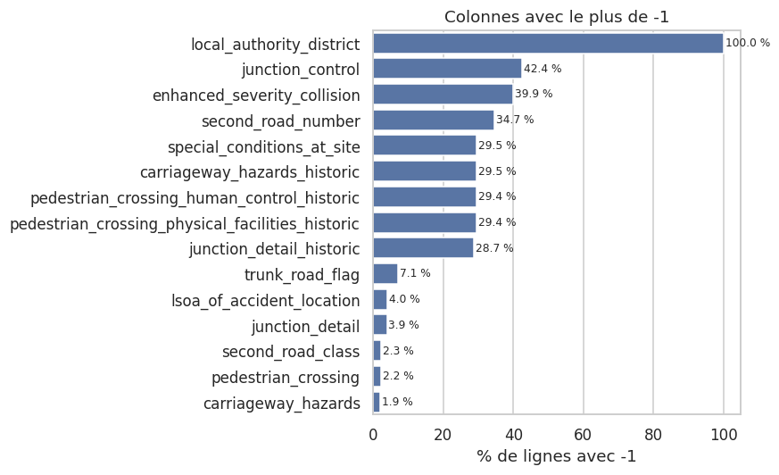

```python
def pct_minus1(s):
    """Part de valeurs -1 (ou '-1' pour les colonnes texte)."""
    if pd.api.types.is_numeric_dtype(s):
        return (s == -1).mean() * 100
    return s.astype(str).eq("-1").mean() * 100

miss = df.apply(pct_minus1).sort_values(ascending=False)
top = miss[miss > 0].head(15)

fig, ax = plt.subplots(figsize=(8, 5))
sns.barplot(x=top.values, y=top.index, color="#4C72B0", ax=ax)
ax.set_xlabel("% de lignes avec -1"); ax.set_ylabel("")
ax.set_title("Colonnes avec le plus de -1")
for i, v in enumerate(top.values):
    ax.text(v + 0.5, i, f"{v:.1f} %", va="center", fontsize=8)
plt.tight_layout(); plt.show()
```

```python
# 9 et 99 : "inconnu" dans certaines colonnes, mais de vraies valeurs ailleurs
for col in ["road_type", "weather_conditions", "road_surface_conditions",
            "junction_detail", "pedestrian_crossing", "carriageway_hazards", "police_force"]:
    code_ = 99 if col in ("junction_detail", "pedestrian_crossing", "carriageway_hazards", "police_force") else 9
    print(f"{col:30s} code {code_:>2} : {(df[col] == code_).sum():>7,} lignes ({(df[col] == code_).mean()*100:.1f} %)")

print()
print("number_of_vehicles = 9 :", (df["number_of_vehicles"] == 9).sum(), "lignes -> c'est un vrai nombre, PAS un manquant")
print("first_road_number  = 9 :", (df["first_road_number"] == 9).sum(), "lignes -> c'est la route 9, PAS un manquant")
```

```
road_type                      code  9 :  13,060 lignes (2.5 %)
weather_conditions             code  9 :  14,566 lignes (2.8 %)
road_surface_conditions        code  9 :   6,721 lignes (1.3 %)
junction_detail                code 99 :   1,429 lignes (0.3 %)
pedestrian_crossing            code 99 :  12,652 lignes (2.5 %)
carriageway_hazards            code 99 :   9,172 lignes (1.8 %)
police_force                   code 99 :  20,530 lignes (4.0 %)

number_of_vehicles = 9 : 31 lignes -> c'est un vrai nombre, PAS un manquant
first_road_number  = 9 : 467 lignes -> c'est la route 9, PAS un manquant
```

**Lecture :**

- `local_authority_district` est vide à 99,96 % : colonne inutilisable.
- Les colonnes `*_historic` et `special_conditions_at_site` sont à ~29-30 % de `-1` au total (voir section 4).
- `junction_control` vaut `-1` pour 42 % des lignes : c'est surtout « pas de carrefour », donc **non applicable**, pas manquant.
- **Piège :** `9` et `99` ne sont des manquants que dans certaines colonnes. Le nettoyage doit se faire **colonne par colonne**.

## 4. Rupture de schéma 2024-2025

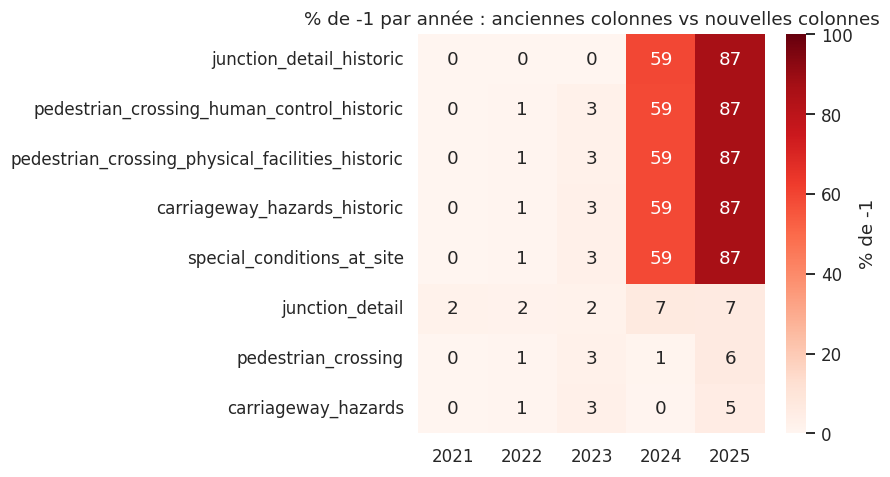

```python
cols_hist = ["junction_detail_historic", "pedestrian_crossing_human_control_historic",
             "pedestrian_crossing_physical_facilities_historic", "carriageway_hazards_historic",
             "special_conditions_at_site"]
cols_new = ["junction_detail", "pedestrian_crossing", "carriageway_hazards"]

heat = pd.DataFrame({c: df.groupby("collision_year")[c].apply(pct_minus1)
                     for c in cols_hist + cols_new}).T

fig, ax = plt.subplots(figsize=(8, 4.5))
sns.heatmap(heat, annot=True, fmt=".0f", cmap="Reds", vmin=0, vmax=100,
            cbar_kws={"label": "% de -1"}, ax=ax)
ax.set_title("% de -1 par année : anciennes colonnes vs nouvelles colonnes")
ax.set_xlabel("")
plt.tight_layout(); plt.show()
```

```python
# Les nouvelles colonnes sont-elles complètes sur toute la période ? (vérification clé)
pd.crosstab(df["junction_detail"], df["collision_year"])
```

| collision_year junction_detail | 2021 | 2022 | 2023 | 2024 | 2025 |
| --- | --- | --- | --- | --- | --- |
| -1 | 2061 | 1817 | 2398 | 7005 | 6701 |
| 0 | 52176 | 55139 | 53234 | 46139 | 45333 |
| 13 | 27699 | 29657 | 29039 | 28004 | 28198 |
| 16 | 9371 | 9743 | 9507 | 9495 | 9456 |
| 17 | 1520 | 1630 | 1634 | 1669 | 1504 |
| 18 | 2209 | 2275 | 2263 | 2256 | 2144 |
| 19 | 6051 | 5743 | 6183 | 6357 | 6762 |
| 99 | 0 | 0 | 0 | 2 | 1427 |

**Lecture :** les colonnes `*_historic` s'effondrent en 2024 (~59 % de `-1`) et 2025 (~87 %). **Mais** les nouvelles colonnes (`junction_detail`, `pedestrian_crossing`, `carriageway_hazards`) sont renseignées sur les 5 ans, avec d'autres codes. Il n'y a donc pas besoin de table de correspondance : on supprime les anciennes colonnes. `special_conditions_at_site` a été fusionnée dans `carriageway_hazards` (mêmes effectifs : par exemple le code 4 de l'ancienne colonne et le code 13 de la nouvelle ont tous deux 1 410 lignes en 2021).

## 5. Valeurs extrêmes

```
       number_of_vehicles  number_of_casualties
count           513801.00             513801.00
mean                 1.82                  1.27
std                  0.69                  0.73
min                  1.00                  1.00
50%                  2.00                  1.00
90%                  2.00                  2.00
99%                  4.00                  4.00
99.9%                6.00                  7.00
max                 26.00                142.00

Collisions avec plus de 20 victimes : 8
```

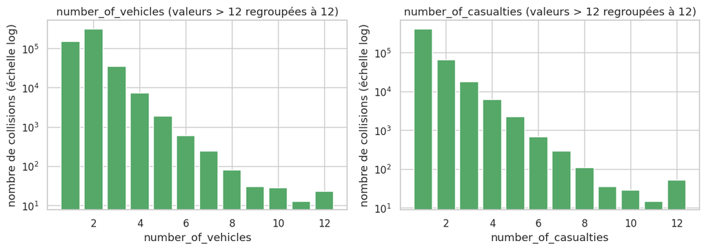

```python
num_cols = ["number_of_vehicles", "number_of_casualties"]
print(df[num_cols].describe(percentiles=[.5, .9, .99, .999]).round(2))
print()
print("Collisions avec plus de 20 victimes :", (df["number_of_casualties"] > 20).sum())

fig, axes = plt.subplots(1, 2, figsize=(11, 4))
for ax, c in zip(axes, num_cols):
    vc = df[c].clip(upper=12).value_counts().sort_index()
    ax.bar(vc.index, vc.values, color="#55A868")
    ax.set_yscale("log")
    ax.set_title(f"{c} (valeurs > 12 regroupées à 12)")
    ax.set_xlabel(c); ax.set_ylabel("nombre de collisions (échelle log)")
plt.tight_layout(); plt.show()
```

**Lecture :** la grande majorité des collisions ont 1 à 2 véhicules et 1 victime. Quelques cas extrêmes (jusqu'à 142 victimes) tirent les moyennes vers le haut. Les quantiles montrent que le 99,9ᵉ centile est de 7 victimes et 6 véhicules : c'est le seuil de plafonnement retenu dans le nettoyage.

## 6. La cible : la gravité

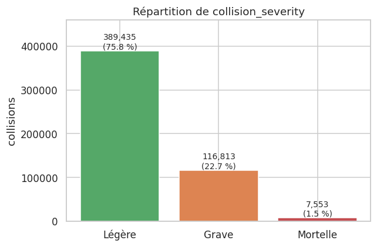

```python
sev_labels = {1: "Mortelle", 2: "Grave", 3: "Légère"}
sev = df["collision_severity"].map(sev_labels).value_counts().reindex(["Légère", "Grave", "Mortelle"])
pct = (sev / sev.sum() * 100).round(1)

fig, ax = plt.subplots(figsize=(6, 4))
ax.bar(sev.index, sev.values, color=["#55A868", "#DD8452", "#C44E52"])
for i, (v, p) in enumerate(zip(sev.values, pct.values)):
    ax.text(i, v, f"{v:,}\n({p} %)", ha="center", va="bottom", fontsize=9)
ax.set_title("Répartition de collision_severity")
ax.set_ylabel("collisions"); ax.set_ylim(0, sev.max() * 1.18)
plt.tight_layout(); plt.show()
```

**Lecture :** cible **très déséquilibrée** : 75,8 % légères, 22,7 % graves, 1,5 % mortelles. Un modèle qui prédit toujours « légère » aurait 76 % d'exactitude sans rien apprendre : il faudra des métriques adaptées (F1, rappel par classe) et un traitement du déséquilibre.

## 7. Biais lié au changement de mode de saisie

| collision_year | injury_based (% des lignes) | enhanced_severity = -1 (% des lignes) | % graves (gravité brute) | % graves (gravité ajustée) |
| --- | --- | --- | --- | --- |
| 2021 | 49.6 | 50.4 | 21.1 | 22.4 |
| 2022 | 52.6 | 47.4 | 22.0 | 23.2 |
| 2023 | 53.7 | 46.3 | 22.5 | 23.6 |
| 2024 | 58.8 | 41.2 | 23.4 | 24.5 |
| 2025 | 86.5 | 13.5 | 24.8 | 25.4 |

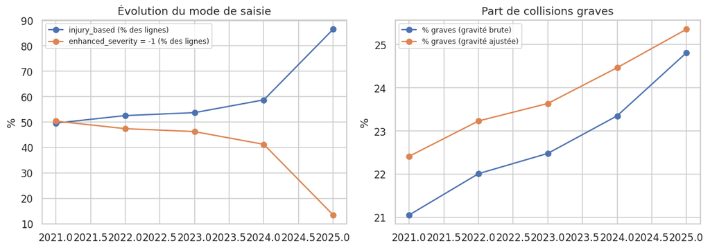

```python
by_year = pd.DataFrame({
    "injury_based (% des lignes)": df.groupby("collision_year")["collision_injury_based"].mean() * 100,
    "enhanced_severity = -1 (% des lignes)": df.groupby("collision_year")["enhanced_severity_collision"].apply(lambda s: (s == -1).mean() * 100),
    "% graves (gravité brute)": df.groupby("collision_year")["collision_severity"].apply(lambda s: (s == 2).mean() * 100),
    "% graves (gravité ajustée)": df.groupby("collision_year")["collision_adjusted_severity_serious"].mean() * 100,
})
display(by_year.round(1))

fig, axes = plt.subplots(1, 2, figsize=(11, 4))
by_year.iloc[:, :2].plot(marker="o", ax=axes[0])
axes[0].set_title("Évolution du mode de saisie"); axes[0].set_ylabel("%"); axes[0].set_xlabel("")
axes[0].legend(fontsize=8)
by_year.iloc[:, 2:].plot(marker="o", ax=axes[1])
axes[1].set_title("Part de collisions graves"); axes[1].set_ylabel("%"); axes[1].set_xlabel("")
axes[1].legend(fontsize=8)
plt.tight_layout(); plt.show()
```

```python
# La gravité dépend-elle du mode de saisie ?
print("Part de collisions graves selon collision_injury_based :")
print((df.groupby("collision_injury_based")["collision_severity"].apply(lambda s: (s == 2).mean()) * 100).round(1))
```

```
Part de collisions graves selon collision_injury_based :
collision_injury_based
0    18.1
1    25.8
Name: collision_severity, dtype: float64
```

**Lecture :** la part de collisions saisies selon le mode « injury-based » passe d'environ 50 % à 87 %, et la part de collisions graves augmente en parallèle (21 % → 25 % en gravité brute). Les collisions « injury-based » sont plus souvent classées graves (25,8 % contre 18,1 %). La gravité **ajustée** (corrigée par le DfT) réduit l'écart entre années mais **ne l'élimine pas** : elle monte aussi, de 22,4 % à 25,4 %. Conclusion prudente : une partie de la hausse vient du changement de méthode, mais on ne peut pas prouver qu'elle explique tout.

## 8. Analyse temporelle

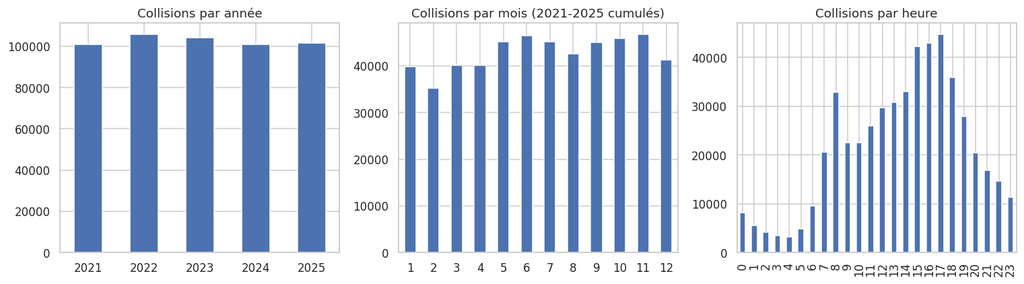

```python
df["date_dt"] = pd.to_datetime(df["date"], format="%d/%m/%Y")
df["hour"] = df["time"].str[:2].astype(int)
df["month"] = df["date_dt"].dt.month

fig, axes = plt.subplots(1, 3, figsize=(14, 4))
df.groupby("collision_year").size().plot.bar(ax=axes[0], color="#4C72B0", rot=0)
axes[0].set_title("Collisions par année")
df.groupby("month").size().plot.bar(ax=axes[1], color="#4C72B0", rot=0)
axes[1].set_title("Collisions par mois (2021-2025 cumulés)")
df.groupby("hour").size().plot.bar(ax=axes[2], color="#4C72B0", rot=90)
axes[2].set_title("Collisions par heure")
for a in axes: a.set_xlabel("")
plt.tight_layout(); plt.show()
```

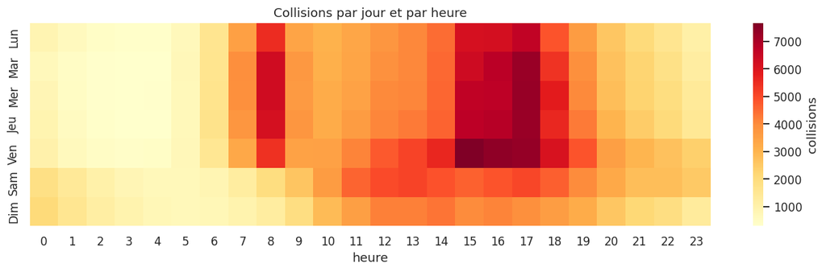

```python
# Jour de la semaine x heure (day_of_week : 1 = dimanche ... 7 = samedi)
jours = {2: "Lun", 3: "Mar", 4: "Mer", 5: "Jeu", 6: "Ven", 7: "Sam", 1: "Dim"}
pivot = (df.pivot_table(index="day_of_week", columns="hour", values="collision_index", aggfunc="count")
           .loc[[2, 3, 4, 5, 6, 7, 1]])
pivot.index = [jours[i] for i in pivot.index]

fig, ax = plt.subplots(figsize=(12, 3.8))
sns.heatmap(pivot, cmap="YlOrRd", cbar_kws={"label": "collisions"}, ax=ax)
ax.set_title("Collisions par jour et par heure"); ax.set_xlabel("heure")
plt.tight_layout(); plt.show()
```

**Lecture :**

- Volume stable : environ 101 000 à 106 000 collisions par an.
- Deux pics en semaine : le matin (8 h) et surtout **15 h-17 h** (plus de 42 000 collisions par tranche horaire).
- Moins de collisions le week-end et la nuit, mais voir section suivante : elles y sont plus graves.
- 2021 est marquée par les confinements Covid : elle est moins représentative.

## 9. Gravité selon les conditions

```
Taux global de collisions graves ou mortelles : 24.2 %
```

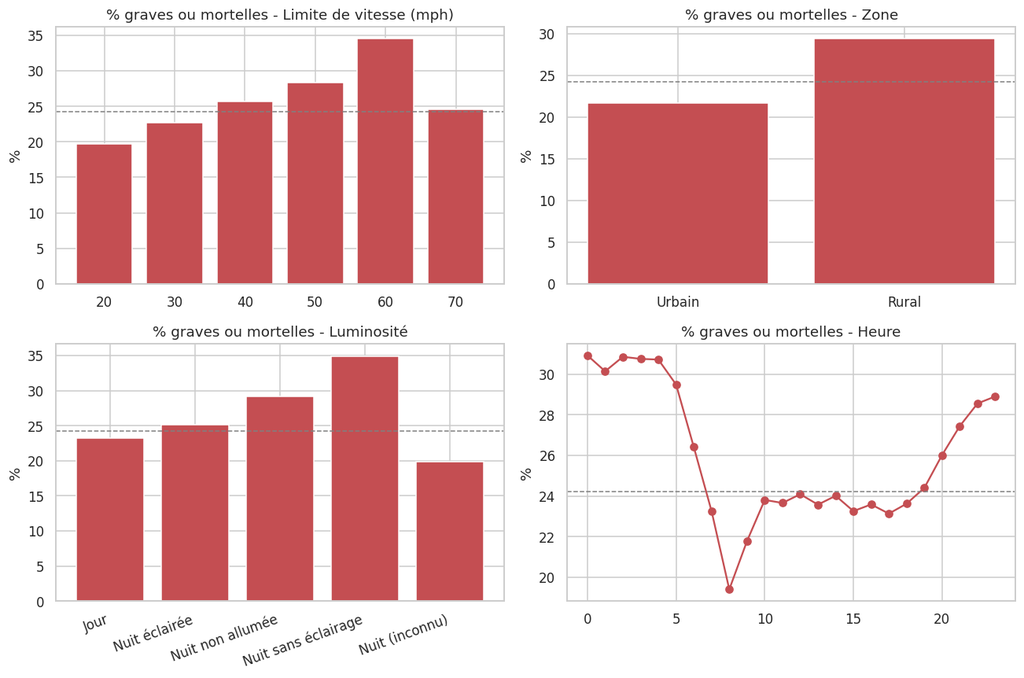

```python
df["grave_ou_mortelle"] = (df["collision_severity"] <= 2).astype(int)
print(f"Taux global de collisions graves ou mortelles : {df['grave_ou_mortelle'].mean()*100:.1f} %")

def rate_by(col, exclude=(), labels=None):
    d = df[~df[col].isin(exclude)]
    r = d.groupby(col)["grave_ou_mortelle"].agg(["mean", "size"])
    r["mean"] *= 100
    if labels:
        r.index = [labels.get(i, i) for i in r.index]
    return r

fig, axes = plt.subplots(2, 2, figsize=(12, 8))
panels = [
    ("speed_limit", (-1,), None, "Limite de vitesse (mph)"),
    ("urban_or_rural_area", (-1, 3), {1: "Urbain", 2: "Rural"}, "Zone"),
    ("light_conditions", (-1,), {1: "Jour", 4: "Nuit éclairée", 5: "Nuit non allumée",
                                  6: "Nuit sans éclairage", 7: "Nuit (inconnu)"}, "Luminosité"),
    ("hour", (), None, "Heure"),
]
for ax, (col, exc, lab, title) in zip(axes.ravel(), panels):
    r = rate_by(col, exc, lab)
    if col == "hour":
        ax.plot(r.index, r["mean"], marker="o", color="#C44E52")
    else:
        ax.bar(r.index.astype(str), r["mean"], color="#C44E52")
        plt.setp(ax.get_xticklabels(), rotation=20 if col == "light_conditions" else 0, ha="right" if col == "light_conditions" else "center")
    ax.axhline(df["grave_ou_mortelle"].mean() * 100, color="grey", ls="--", lw=1)
    ax.set_title(f"% graves ou mortelles - {title}")
    ax.set_ylabel("%"); ax.set_xlabel("")
plt.tight_layout(); plt.show()
```

**Lecture :** (la ligne pointillée est le taux global, 24,2 %)

- **Vitesse :** le taux de collisions graves ou mortelles passe de ~20 % à 20 mph à ~35 % à 60 mph. La part de mortelles passe de 0,5 % à 3,8 %. Le 70 mph est plus bas (24,6 %), probablement parce qu'il concerne surtout des routes à chaussées séparées (hypothèse non vérifiée ici).
- **Zone :** rural 29,4 % contre urbain 21,7 % ; mortelles 2,8 % contre 0,8 %.
- **Luminosité :** la nuit sans éclairage est la plus grave (34,9 % contre 23,2 % de jour).
- **Heure :** les collisions de nuit (22 h-5 h) sont les plus graves (~29 % à 31 %), alors qu'elles sont peu nombreuses.
- Le week-end est aussi plus grave (dimanche 27,1 %, samedi 26,3 % contre ~23 % en semaine).

## 10. Géographie

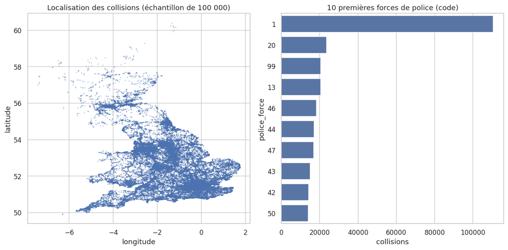

```
Lignes sans coordonnées : 53
```

```python
geo = df.dropna(subset=["latitude", "longitude"]).sample(100_000, random_state=0)

fig, axes = plt.subplots(1, 2, figsize=(12, 6))
axes[0].scatter(geo["longitude"], geo["latitude"], s=1, alpha=0.3, color="#4C72B0")
axes[0].set_title("Localisation des collisions (échantillon de 100 000)")
axes[0].set_xlabel("longitude"); axes[0].set_ylabel("latitude")

top = df["police_force"].value_counts().head(10)
sns.barplot(x=top.values, y=top.index.astype(str), color="#4C72B0", ax=axes[1])
axes[1].set_title("10 premières forces de police (code)"); axes[1].set_xlabel("collisions"); axes[1].set_ylabel("police_force")
plt.tight_layout(); plt.show()
print("Lignes sans coordonnées :", df["latitude"].isna().sum())
```

**Lecture :** les points dessinent la carte de la Grande-Bretagne : la densité suit la population et les grands axes routiers. La force de police n°1 (Metropolitan Police, Londres) concentre à elle seule 110 585 collisions, soit plus de 20 %. Le code `99` (20 530 lignes, 4 %) est le 3ᵉ plus fréquent : c'est un « inconnu », pas une vraie force, et ces 20 530 lignes ont aussi toutes un LSOA manquant.

## 11. Liens avec la gravité (V de Cramér)

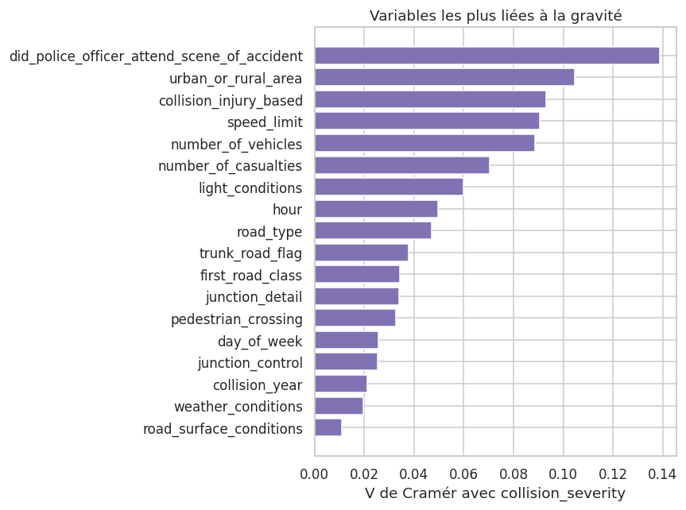

```python
def cramers_v(x, y):
    """Association entre deux variables catégorielles (0 = aucune, 1 = totale), corrigée du biais."""
    t = pd.crosstab(x, y)
    chi2 = chi2_contingency(t)[0]
    n = t.values.sum()
    r, k = t.shape
    phi2c = max(0, chi2 / n - (k - 1) * (r - 1) / (n - 1))
    rc, kc = r - (r - 1) ** 2 / (n - 1), k - (k - 1) ** 2 / (n - 1)
    return np.sqrt(phi2c / min(kc - 1, rc - 1))

candidates = {  # variable : codes à exclure (manquants)
    "did_police_officer_attend_scene_of_accident": [], "urban_or_rural_area": [-1, 3],
    "collision_injury_based": [], "speed_limit": [-1], "number_of_vehicles": [],
    "number_of_casualties": [], "light_conditions": [-1], "hour": [], "road_type": [9],
    "trunk_road_flag": [-1], "first_road_class": [-1], "junction_detail": [-1, 99],
    "pedestrian_crossing": [-1, 99], "day_of_week": [], "junction_control": [-1, 9],
    "collision_year": [], "weather_conditions": [-1, 9], "road_surface_conditions": [-1, 9],
}
res = {}
for c, bad in candidates.items():
    d = df[~df[c].isin(bad)]
    x = d[c].clip(upper=5) if c in ("number_of_vehicles", "number_of_casualties") else d[c]
    res[c] = cramers_v(x, d["collision_severity"])
res = pd.Series(res).sort_values()

fig, ax = plt.subplots(figsize=(8, 6))
ax.barh(res.index, res.values, color="#8172B3")
ax.set_xlabel("V de Cramér avec collision_severity")
ax.set_title("Variables les plus liées à la gravité")
plt.tight_layout(); plt.show()
```

```python
# Pourquoi la présence de la police est-elle la plus liée à la gravité ?
(pd.crosstab(df["did_police_officer_attend_scene_of_accident"], df["collision_severity"], normalize="index")
   .rename(index={1: "police présente", 2: "police absente", 3: "déclaré par la personne"},
           columns=sev_labels) * 100).round(1)
```

| collision_severity did_police_officer_attend_scene_of_accident | Mortelle | Grave | Légère |
| --- | --- | --- | --- |
| police présente | 2.0 | 27.6 | 70.4 |
| police absente | 0.4 | 15.3 | 84.3 |
| déclaré par la personne | 0.0 | 9.7 | 90.3 |

**Lecture :**

- Toutes les associations sont **faibles** (V < 0,15). Les variables de la table Collision seules n'expliquent donc pas bien la gravité : il faudra enrichir avec les tables Vehicle et Casualty et des données externes.
- La variable la plus liée est la présence de la police (V ≈ 0,14). Ce n'est pas une cause : les collisions déclarées en ligne par la personne sont presque toutes légères (90 % légères, 0 % mortelles). C'est un effet de **sélection**, et la part de ces déclarations augmente (14 % en 2021, 23 % en 2025).
- Viennent ensuite zone urbaine/rurale (0,105), mode de saisie (0,093) et limite de vitesse (0,090). La météo et l'état de la chaussée ont peu d'effet (V ≈ 0,02 et 0,01).

## 12. Synthèse : constats → décisions de nettoyage

| Constat (EDA) | Décision dans `clean_collision.py` |
| --- | --- |
| `collision_index` unique, `collision_ref_no` non unique | Garder `collision_index`, supprimer `collision_ref_no` |
| Manquants cachés sous `-1`, `9`, `99`, selon la colonne | Conversion en `NaN` colonne par colonne |
| `-1` hors carrefour = « non applicable » | Recodé en 0 (`junction_control`, `second_road_class`, `second_road_number`) |
| `local_authority_district` quasi vide ; colonnes en double | Suppression |
| Anciennes colonnes `*_historic` vides en 2024-2025, remplacées par des colonnes complètes | Suppression des anciennes colonnes (pas de table de correspondance) |
| Variable de gravité « enhanced » à 40 % de `-1` et proche de la cible | Suppression |
| 53 lignes sans coordonnées | Médiane par district + indicateur `coordinates_imputed` |
| Petits manquants sur variables catégorielles | Mode par groupe (météo par mois, chaussée par météo…) |
| `police_force = 99` et LSOA `-1` (mêmes lignes) | Pas d'imputation, restent `NaN` |
| Valeurs extrêmes (jusqu'à 142 victimes) | Colonnes `*_capped` au 99,9ᵉ centile ; colonnes d'origine conservées |
| Cible déséquilibrée, saisie qui change | À traiter au moment de la modélisation ; utiliser aussi la gravité ajustée |
| Date et heure en texte | `collision_datetime`, `month`, `hour`, `is_weekend`, `part_of_day` |

**Limites de cette EDA :** seule la table Collision est analysée ; seules les collisions corporelles déclarées à la police sont recensées (sous-déclaration des cas légers) ; une association (V de Cramér) n'est pas une causalité.